### An Introduction to Image Processing (Nov. 06, 2017)

We will learn the following topics in this lecture.

1. Digital image fundamentals
2. Signal processing background
3. Image sampling and quantization
4. Image enhancement
5. Image restoration
6. Image segmentation

#### Digital image fundamentals

The term image refers to a 2D light-intensity function denoted by $f(x,y)$

The value or amplitude of $f$ at spatial coordinates $(x,y)$ gives the intensity (brightness) of the image at that point.

The basic nature of $f(x,y)$ can be characterised by two components:

1. The amount of source light incident (*illumination*) on the scene:

$$i(x,y) \text{ where } 0\leq i(x,y) \leq \infty$$

2. The amount of light reflected (*reflectance*) by the objects:

$$r(x,y) \text{ where } 0\leq r(x,y) \leq 1$$

Total absorption $r(x,y) = 0$ and $r(x,y) = 1$ is never acheived.

The functions $i(x,y)$ and $r(x,y)$ combine as a product:

$$f(x,y) = i(x,y)r(x,y) \text{ and hence } 0 \leq f(x,y) \leq \infty$$

In order for a computer to process an image, it has to be described as a series of numbers, each of finite precision. The digitisation of $f(x,y)$ is called:

1. **Image sampling** when it refers to spatial coordinates $(x,y)$ and
2. **Quantisation** when it refers to the amplitude of $f(x,y)$

The images are thus only sampled at a discrete number of locations with a discrete set of brightness levels.

The following is the height profile of Switzerland and sub-sampled height profile of Swiss.

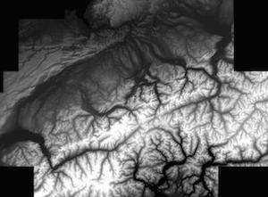

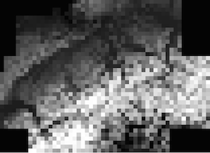

Similarly, we can quantize the intensity along the red line:

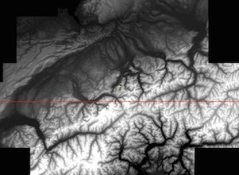

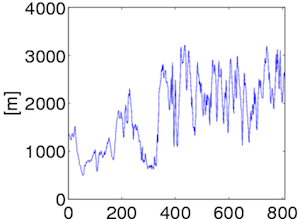

to get the quantized version,

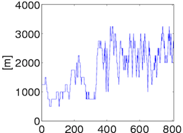

When considered together, the digitization process requires making decision about:

- the size of the image array $N\times M$ and
- the number of discrete grey-levels $G$ allowed for each pixel, $f(x,y)$

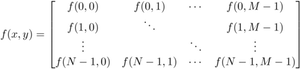

In digital image processing these quantities are usually powers of two, thus, $N = 2^n$, $M = 2^m$ and $G = 2^k$ for some $n, m \text{ and } k$.

How many samples and grey-levels are required for a good approximation?

- **resolution** (degree of discernable detail) of an image depends on the number of samples and grey-levels
- the bigger these parameters, the closer the digitised array approximates the original image
- however, the storage and processing time increases rapidly

##### Relationship between the pixels

Quantisation alone does not imply a spatial structure → it must be defined and we have to consider topology and metrics

Neighborhood is defined via metrics and vice-versa and are defined on the grid

In 2D they are defined as 4-, 8- or mixed-neighbourhoods. We will see them now.

But before that we will define the following:

Digital image is denoted by $f(x,y)$, pixels as $p,q$ and subset of pixels of $f(x,y)$ as $S$

**$4$-Neighbours**

A pixel $p$ at spatial position $(x,y)$ has $4$ neighbours:

$S:(x+1,y),(x-1,y),(x,y+1),(x,y-1)$

This set of pixels is called the $4$-neighbourhood of $p: S=N_4(p)$

**Diagonal Neighbours**

The four diagonal neighbours of $p$ are $N_D(p)$:

$S:(x+1,y+1),(x-1,y+1),(x+1,y-1),(x-1,y-1)$

**8-Neighbourhood**

$N_4(p)+N_D(p)\rightarrow N_8(p)$

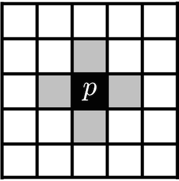

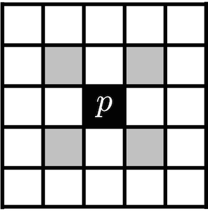

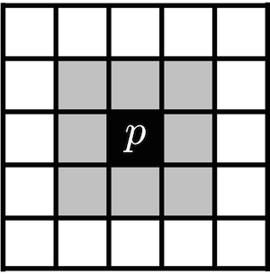

##### Connectivity

Connectivity between pixels is important to:

1. Establish boundaries around objects
2. Extract connected components in an image

Two pixels $p,q$ are connected if

1. They are neighbours, e.g. $N_4(p)$,$N_8(p)$,…
2. Their grey values satisfy a specified criterion of similarity, e.g. in a binary image they have the same value of either $0$ or $1$

Let V be the set of grey-level values used to define connectivity; for example in a binary image $V=\{1\}$ or in a grey-scale image $V=\{16,17,...,32\}$. We can define two types of connectivity:

1. $4$-connectivity if two pixels $p,q$ with values from V and q is in $N_4(p)$
2. $8$-connectivity if two pixels $p,q$ with values from V and q is in $N_8(p)$

**$4$-connectivity paradox**

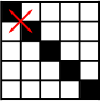

**$8$-connectivity paradox**

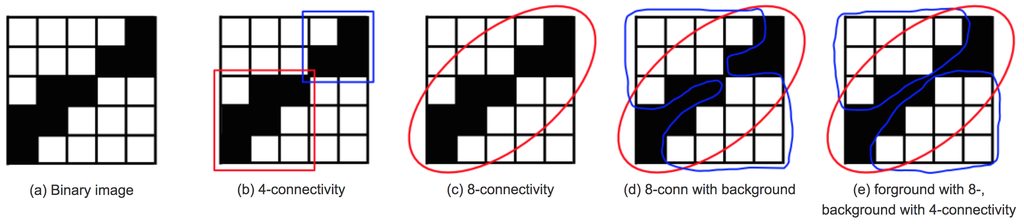

**Solution**

Foreground $8$-neighbourhood + Background $4$-neighbourhood

##### Fundamental steps in image processing

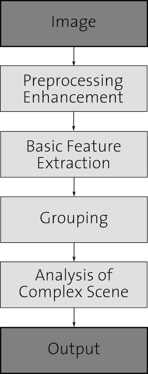

#### Signal processing background

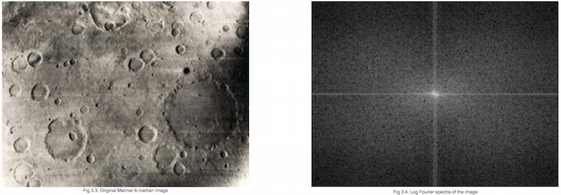

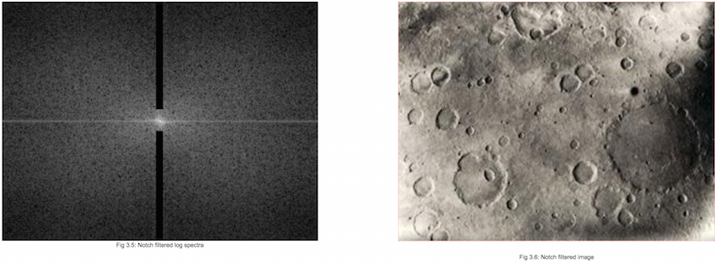

##### Basic ideas

A periodic function can be represented by the sum of sines and cosines of different frequencies, multiplied by a different coefficient (Fourier Series)

Non-periodic functions can also be represented as the integral of sines/cosines multiplied by a weighting function (Fourier Transformation)

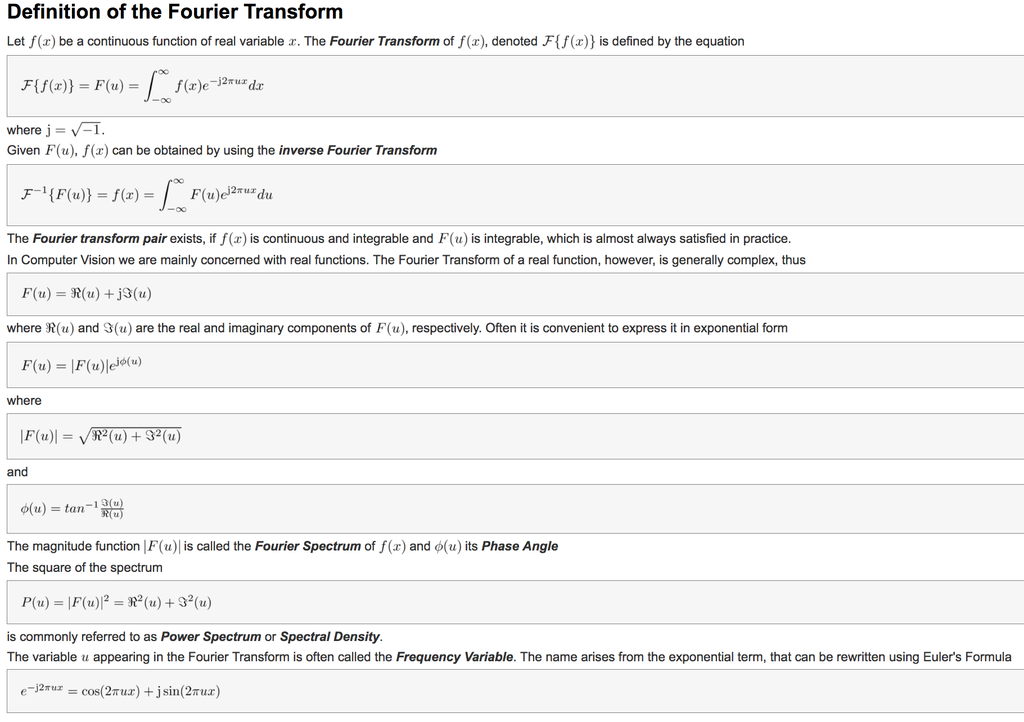

#### References

1. [Introduction to Signal and Image Processing](https://miac.unibas.ch/SIP/)